# agentic ai phidata

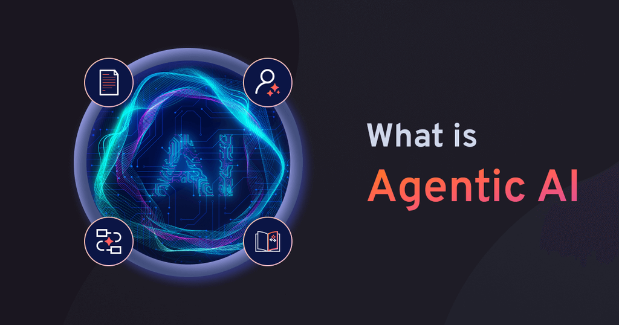

**Agentic AI** refers to a class of artificial intelligence systems designed to operate autonomously, making decisions and performing tasks with minimal human intervention. Unlike traditional AI, which often requires explicit instructions for each step, agentic AI can set goals, plan actions, and adapt to changing conditions in real time. This capability allows it to tackle complex, multi-step problems across various domains.

### 🔍 Key Characteristics of Agentic AI

- Autonomy: Agentic AI systems can act independently to achieve predefined objectives without constant human oversight.
- Goal-Oriented Behavior: These systems are designed to pursue specific goals, often involving complex decision-making processes.
- Adaptability: Agentic AI can adjust its actions based on new information or changes in the environment, making it suitable for dynamic and unstructured settings.
- Integration with Tools and Data: Such systems can interact with various tools and data sources, enabling them to perform tasks like data analysis, process automation, and customer support.

### 🧠 How It Works

**Agentic AI typically involves the following components:**

- AI Agents: These are the core entities that perform tasks and make decisions.
- Planning and Reasoning: The agents use sophisticated algorithms to plan and reason through tasks.
- Execution: Once a plan is formulated, the agents execute the necessary actions to achieve the goal.
- Feedback and Learning: Post-execution, the system evaluates the outcomes and learns from the experience to improve future performance.

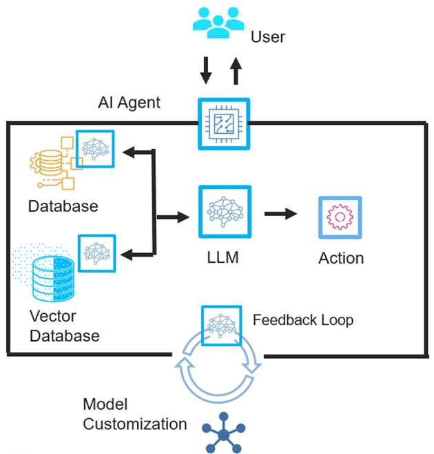

### 🌐 Real-World Applications

- Customer Support: AI agents can handle customer inquiries, process transactions, and provide personalized assistance.
- Business Intelligence: They can analyze large datasets to provide insights and support decision-making processes.
- Cybersecurity: Agentic AI can monitor systems for threats and respond to security incidents autonomously.
- Healthcare: In healthcare, these systems can assist in diagnostics, patient monitoring, and personalized treatment planning.

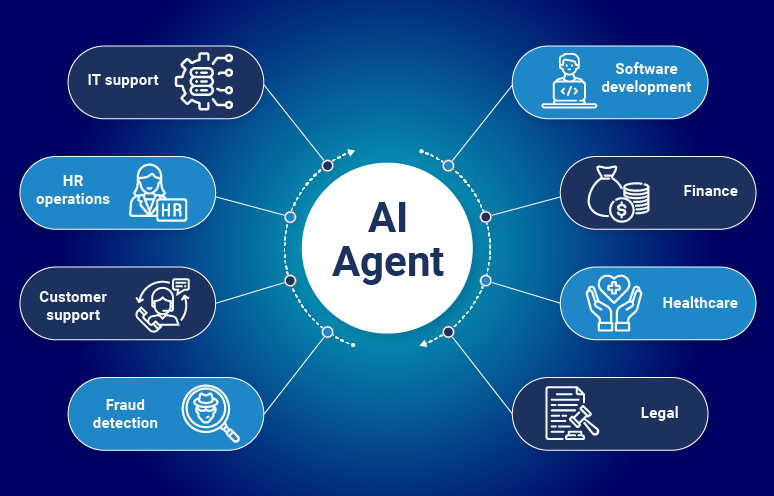

### ⚠️ Challenges and Considerations

**While agentic AI offers significant advantages, it also presents challenges:**

- Security Risks: Autonomous systems may be vulnerable to cyberattacks or misuse.
- Ethical Concerns: Issues related to accountability, decision-making transparency, and potential biases need to be addressed.
- Integration Complexity: Implementing agentic AI requires careful integration with existing systems and processes.
- Regulatory Compliance: Ensuring that these systems comply with legal and regulatory standards is crucial.

## Agents in Agentic AI

**Agents are the building blocks of agentic systems. They are AI entities with:**

- Autonomy: Can make decisions independently.
- Goal-Oriented Behavior: Works toward specific objectives.
- Tool Integration: Can use APIs, databases, scripts, or other resources.
- Memory / Knowledge Access: Can remember context, previous actions, or external knowledge.

**Example:**

- A financial agent might monitor stock prices, analyze trends, and automatically suggest or execute trades.
- A customer service agent could answer user queries, check product databases, and even escalate issues automatically.

## 🧠 Key Components of Agentic AI Frameworks

1. Perception: Agents gather information from their environment through sensors or data inputs.
2. Cognition: They process and interpret the information to understand the context and make informed decisions.
3. Decision-Making: Based on their cognition, agents plan and choose actions to achieve their goals.
4. Action: Agents execute tasks or interact with their environment to fulfill objectives.
5. Memory: Storing past experiences and knowledge to inform future decisions.
6. Communication: Agents may need to interact with other agents or systems to coordinate actions and share information.

## 🛠️ Popular Agentic AI Frameworks

**Several frameworks facilitate the development of Agentic AI systems:**

- LangChain (LangGraph): Supports building applications with LLMs and external tools, offering features like memory and agent coordination.
- CrewAI: Focuses on team-based AI agents, enabling collaborative task execution.
- Microsoft AutoGen: Provides tools for building and managing AI agents with integrated support for the Model Context Protocol (MCP).
- OpenAI Agent SDK: Offers tools for developing agents using OpenAI's models and infrastructure.
- Phidata (Agno): An open-source platform for building, deploying, and monitoring AI agents with advanced memory, knowledge, and tool integration capabilities

## 🔍 Understanding PhiData (Agno)

**PhiData, now known as Agno, is an open-source framework designed to build, ship, and monitor agentic systems. It allows developers to create multi-modal agents equipped with memory, knowledge, tools, and reasoning capabilities.**

### 🔧 Core Features of PhiData

- Multi-Modal Agents: Build agents that can process and respond to various types of inputs, such as text, images, and more.
- Memory and Knowledge Integration: Equip agents with the ability to remember past interactions and access external knowledge bases.
- Tool Integration: Allow agents to interact with external tools and APIs to perform tasks.
- Reasoning Capabilities: Enable agents to make informed decisions based on their knowledge and objectives.
- Agent Teams: Create teams of agents that can collaborate to solve complex problems.
- User Interface: Interact with agents through a user-friendly interface, facilitating communication and monitoring.
- Developers can use PhiData to transform any large language model (LLM) into a powerful, domain-specific AI agent with minimal configuration

## 🧩 How PhiData Works

1. Agent Creation: Define agents with specific roles and capabilities using PhiData's tools.
2. Integration: Connect agents to various data sources, tools, and APIs to enhance their functionality.
3. Deployment: Deploy agents to perform tasks autonomously or in collaboration with other agents.
4. Monitoring and Optimization: Monitor agent performance and make adjustments to improve efficiency and effectiveness.

**Let's understand the PhiData framework with practical:-**

```python
from phi.agent import Agent
from phi.model.groq import Groq
import os
os.environ["GROQ_API_KEY"] = "gsk........qHm"
os.environ["GOOGLE_API_KEY"]= "AIz........gUk"
```

## 1.Stock Price Agent (Fetches real-time stock prices)

```python
from phi.tools.yfinance import YFinanceTools

# Stock Price Agent
stock_price_agent = Agent(
    name = "Stock Price Agent",
    model = Groq(id = "llama-3.3-70b-versatile"),
    tools = [YFinanceTools()],
    instructions = [
        "Fetch the latest stock price for the given company",
        "Provide the current stock price along with any relevant market data.",
        "Provide insights and predictions for the next trading day."
    ],

    show_tool_calls= True,
    markdown = True,
    debug_mode = True,
)
stock_price_agent.print_response(
    "Fetch the latest stock price for Tesla",
    stream = True
)
```

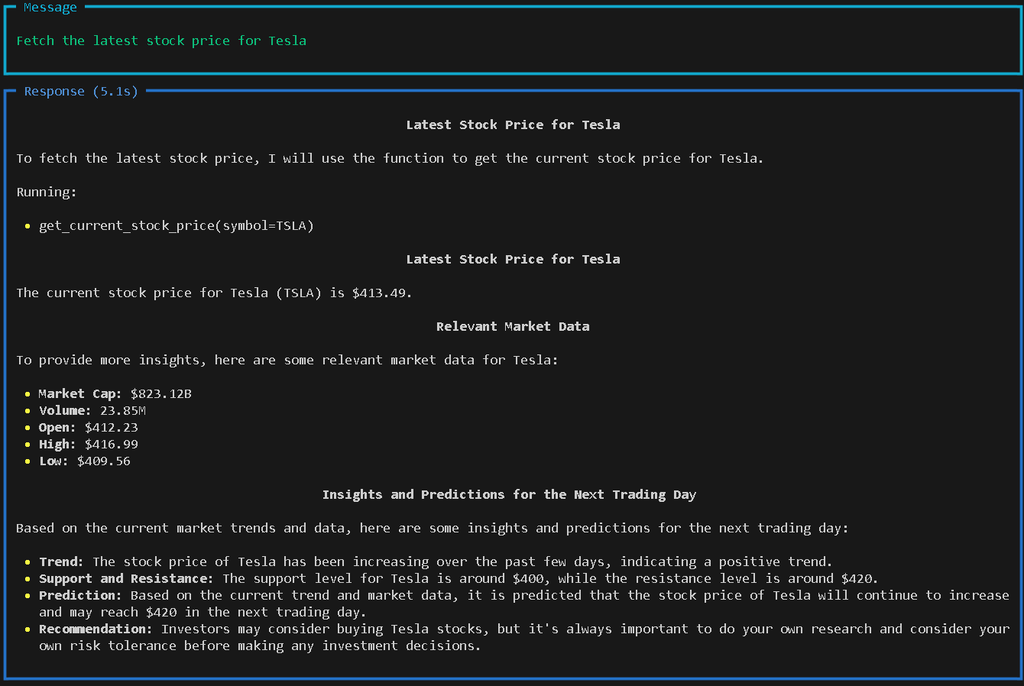

## Calculator

```python
from phi.agent import Agent
from phi.tools.calculator import Calculator

agent = Agent(
    model=Groq(id="llama-3.3-70b-versatile"),
    tools=[
        Calculator(
            add=True,
            subtract=True,
            multiply=True,
            divide=True,
            exponentiate=True,
            factorial=True,
            is_prime=True,
            square_root=True,
        )
    ],
    show_tool_calls=True,
    markdown=True,
)
agent.print_response("What is 10*5 then to the power of 2, do it step by step")
```

```
Output()
```

```
INFO     Multiplying 10.0 and 5.0 to get 50.0
```

```
INFO     Raising 50.0 to the power of 2.0 to get 2500.0
```

## Duck Duck Go search tool

```python
from phi.agent import Agent
from phi.tools.duckduckgo import DuckDuckGo

agent = Agent(
    model = Groq(id = "llama-3.3-70b-versatile"),
    tools=[DuckDuckGo()],
    show_tool_calls=True)
agent.print_response("Whats happening in France?", markdown=True)
```

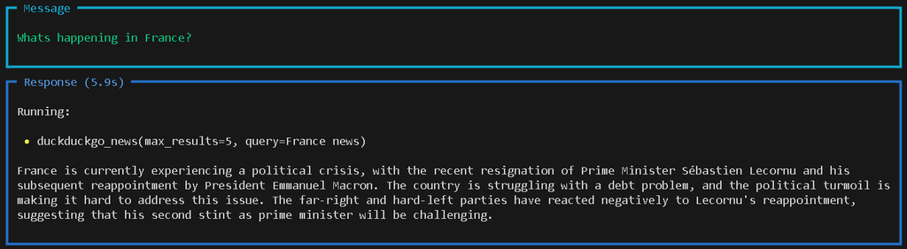

## CSV Tool

```python
import httpx
from pathlib import Path
from phi.agent import Agent
from phi.tools.csv_tools import CsvTools
from phi.model.groq import Groq

url = "https://phidata-public.s3.amazonaws.com/demo_data/IMDB-Movie-Data.csv"
response = httpx.get(url)

imdb_csv = Path(__file__).parent.joinpath("wip").joinpath("imdb.csv")
imdb_csv.parent.mkdir(parents=True, exist_ok=True)
imdb_csv.write_bytes(response.content)

agent = Agent(
    tools=[CsvTools(csvs=[imdb_csv])],
    markdown=True,
    show_tool_calls=True,
    instructions=[
        "First always get the list of files",
        "Then check the columns in the file",
        "Then run the query to answer the question",
    ],
)
agent.cli_app(stream=False)
```

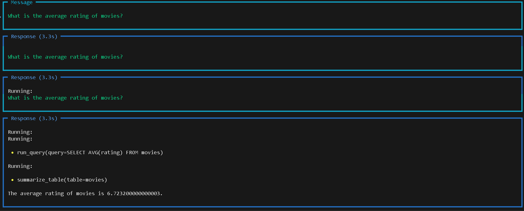

```python
from phi.agent import Agent
from phi.tools.openbb_tools import OpenBBTools


agent = Agent(tools=[OpenBBTools()], debug_mode=True, show_tool_calls=True)

# Example usage showing stock analysis
agent.print_response(
    "Get me the current stock price and key information for Apple (AAPL)"
)
```

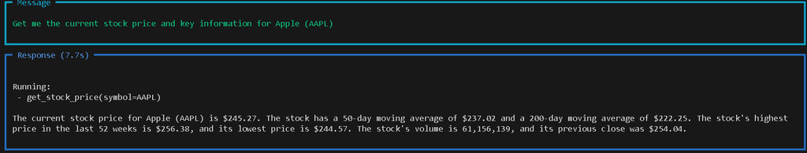

```python
from phi.agent import Agent
from phi.tools.python import PythonTools

agent = Agent(tools=[PythonTools()], show_tool_calls=True)
agent.print_response("Write a python script for fibonacci series and display the result till the 10th number")
```

[figure not shown]